# Kashihara_Ito_2020

Jun Kashihara

2020/4/25

## はじめに

このファイルは，『認知行動療法研究』の特集号「認知行動療法研究の新時代を切り開く研究法」上で樫原 潤・伊藤 正哉が執筆した論文の補足資料です。論文内のFig. 1をどのように求めるのか，より詳細な分析を実施するにはどうすれば良いのか，統計解析ソフトウェアRのコードと出力結果をコメント付きでまとめています。

なお，下記のコードは，本文で引用したEpskamp et al. (2018) に記されているものと基本的に同一です。ただし，Epskamp et al. (2018) の論文執筆時点と比べ，本ファイルの作成時点 (2020年4月25日) ではqgraph, bootnetの両パッケージの仕様が更新されています。仕様の更新に伴いコードを数か所書き換えたことにご留意ください (どこを書き換えたかは，コメント欄でご確認ください)。

## データセットの読み込み

PTSDをもつ女性患者359名のデータセット。分析の前にダウンロードしておく必要がある。 https://datashare.nida.nih.gov/study/nida-ctn-0015 にアクセスし，“CTN-0015 Data Files”をクリックすれば，“qs.csv”というデータセットをダウンロードできる。

```r
FullData <- read.csv("qs.csv", stringsAsFactors = FALSE)
```

## データの成型

### 必要なパッケージの読み込み (初めての場合はまずインストールを)

```r
# install.packages("dplyr")
# install.packages("tidyr")
library("dplyr")
library("tidyr")
```

### データセットから，Baseline時点の必要なデータだけを抜き出す

```r
Data <- FullData %>%
  filter(EPOCH == "BASELINE",
         grepl("^PSSR\\d+A$",QSTESTCD)) %>%
  select(USUBJID,QSTEST,QSORRES) %>%
  spread(QSTEST, QSORRES) %>%
  select(-USUBJID) %>%
  mutate_all(funs(replace(.,.=="NOT ANSWERED",NA))) %>%
  mutate_all(funs(ordered(.,c("NOT AT ALL","ONCE A WEEK",
                              "2-4 TIMES PER WEEK/HALF THE TIME",
                              "5 OR MORE TIMES PER WEEK/ALMOST ALWAYS"))))
names(Data) <- seq_len(ncol(Data))
```

## 分析の実施

### 必要なパッケージの読み込み (初めての場合はまずインストールを)

```r
# install.packages("bootnet")
# install.packages("qgraph")
# install.packages("glasso")
# install.packages("lavaan", dependencies=TRUE)
library("bootnet")
library("qgraph")
library("glasso")
library("lavaan")
```

### ネットワークの推定と描画 (Fig. 1, Fig. S1)

```r
Network <- estimateNetwork(Data, default = "EBICglasso")
```

```
## Estimating Network. Using package::function:
##   - qgraph::EBICglasso for EBIC model selection
##     - using glasso::glasso
##   - qgraph::cor_auto for correlation computation
##     - using lavaan::lavCor
```

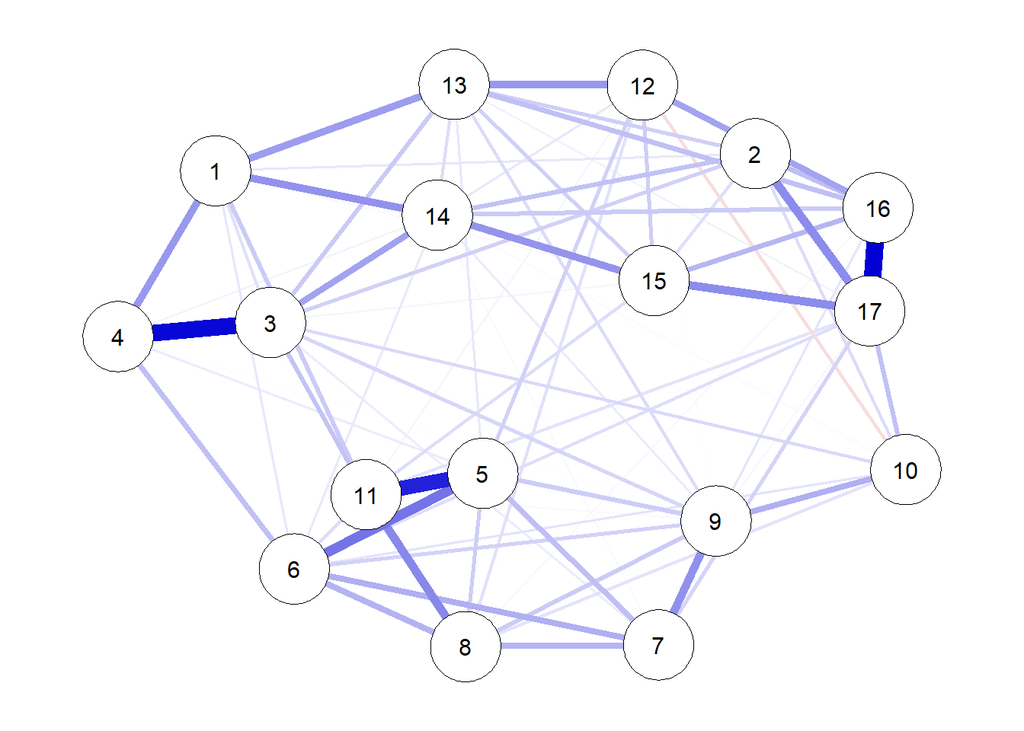

```r
plot(Network, layout = "spring",labels = TRUE)
```

### ネットワーク全体のサマリーを確認

```r
summary(Network)
```

```
##
## === Estimated network ===
## Number of nodes: 17
## Number of non-zero edges: 78 / 136
## Mean weight: 0.05421188
## Network stored in object$graph
##
## Default set used: EBICglasso
##
## Use plot(object) to plot estimated network
## Use bootnet(object) to bootstrap edge weights and centrality indices
##
## Relevant references:
##
##      Friedman, J. H., Hastie, T., & Tibshirani, R. (2008). Sparse inverse covariance estimation with the graphical lasso. Biostatistics, 9 (3), 432-441.
##  Foygel, R., & Drton, M. (2010). Extended Bayesian information criteria for Gaussian graphical models.
##  Friedman, J. H., Hastie, T., & Tibshirani, R. (2014). glasso: Graphical lasso estimation of gaussian graphical models. Retrieved from https://CRAN.R-project.org/package=glasso
##  Epskamp, S., Cramer, A., Waldorp, L., Schmittmann, V. D., & Borsboom, D. (2012). qgraph: Network visualizations of relationships in psychometric data. Journal of Statistical Software, 48 (1), 1-18.
##  Epskamp, S., Borsboom, D., & Fried, E. I. (2016). Estimating psychological networks and their accuracy: a tutorial paper. arXiv preprint, arXiv:1604.08462.
```